# Analyse des données AirBnB pour une optimisation des avis clients

## 1. Importance des avis clients

Airbnb couvre actuellement plus de **100 000 villes** et **220 pays** dans le monde. Rien que dans la région de Madrid, AirBnB dispose de **17747** logements.

Contrairement à une chambre d'hotel, les logements sur AirBnB ne suivent pas un standing imposé. Les hôtes créent leurs propres annonces, et certains peuvent être plus honnêtes que d'autres.

Dans ce contexte, les avis clients ont une double utilité :

- Publicité : un logement avec une meilleure note sera plus attrayant
- Véritable représentation du logement pour les clients

**Essentiel que les logements au sein de AirBnB soient bien évalués**

## 2. Problématique :

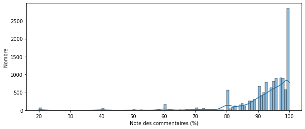

- Logements globalement très bien évalués (avec une moyenne de 92%)
- Un certain nombre ont des notes très faibles

**Comment améliorer cette évaluation moyenne en maintenant des revenus élevés pour AirBnB ?**

## 2. Solution : meilleur accompagnement des hôtes inexpérimentés

### Pourquoi ?

- Impossibilité d'écarter simplement les logements les moins biens notés, ceci représenterait une perte de **277 686 dollars** sur l'année juste pour la région madrilenne.
- Les logements les moins biens notés sont les logements les moins évalués avec les hotes les moins expérimentés (dans une certaine mesure)

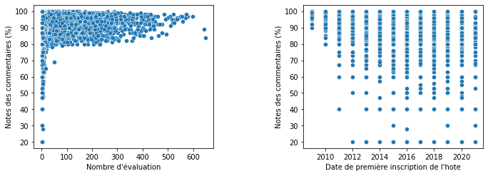

### Comment ?

1- Système de parainnage des "Inexpérimentés" par les "SuperHosts"

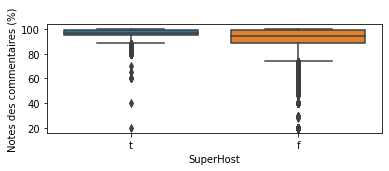

2- Services de "standing" hotelier : les chambres d'hotel présentant les prix les plus élevés (p-value<0.05) pour des évalutations quasi-identiques aux autres types de chambres.

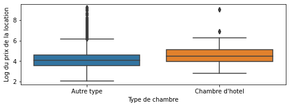